# 432 Class 18 (Updated after class)

Thomas E. Love, Ph.D.

2024-03-21

## Today’s Topics

1. Project B Instructions
2. Asbestos Exposure in the US Navy: A new example predicting an ordered multi-categorical outcome
   - Proportional Odds Logistic Regression Models
     - with `MASS::polr()`
     - with `rms::lrm()`
   - Fitting Ordinal Logistic Regressions with `rms::orm()`

Chapter 27 of the Course Notes describes this material.

## Setup

```r
knitr::opts_chunk$set(comment=NA)
options(width = 80)

library(janitor); library(broom); library(gt)
library(mosaic) ## but just for favstats

library(nnet)
library(MASS)

library(conflicted)

library(rms)
library(tidyverse)

conflicts_prefer(dplyr::filter, dplyr::select,
                 dplyr::summarize, dplyr::count,
                 base::mean)

theme_set(theme_bw())
```

# Project B instructions

## Project B deadlines

Everything is found at https://thomaselove.github.io/432-2024/projB.html.

In project B, you will create two research questions that can be addressed with data you can conveniently obtain that can be used to address each of your questions, with models that you learned in the 431-432 sequence. You will fit one regression model for each research question.

- Each of your models must include 2-8 predictors.
- Each model must include at least one predictor that is not included in the other model.
- Each model will need to describe observations from the same pool of “subjects”, so that a single tibble services the whole Project.

## Your Two Models

The model for your first outcome must be either:

- A model for a multi-categorical outcome
- A model for a count outcome, or
- A Cox model for a time-to-event outcome with censoring

The model for your second outcome must use a different approach than you used for Outcome 1. For this model, you can use any of the three options above, or you may use:

- A linear or binary logistic model fit using a Bayesian engine, or
- A weighted linear regression model.

**Note**: I may add some additional options here.

## Deliverables

1. A Proposal Form to be submitted no later than noon on Wednesday 2024-04-10. (details on next three slides.)
2. An in-person or Zoom Presentation
   - April 30 and May 1 are CWRU Reading Days and May 2 is when CWRU final exams begin. Our last 432 class is Thursday 2024-04-25.
3. A Portfolio developed with Quarto (along with some data) submitted to Canvas by noon on Tuesday 2024-05-07.

## Project B Proposal Form

Now open at https://bit.ly/432-2024-projectB-proposal-form

The form allows you to:

- register a brief description of your project for our approval
- specify presentation times when you (and your partner if applicable) are available.

Please read the instructions at https://thomaselove.github.io/432-2024/projB.html before you submit the form.

## Information the form requires

- You’ll need to assert that you have already successfully ingested the data into R.
- You’ll need to tell us the two types of models you plan to fit.
- You’ll need to describe the variables you intend to use as outcomes in your models.
  - These two outcomes need to be clearly linked to your research questions, and you’ll need to tell us something about each of their distributions.
- You’ll need to specify how many cases are in your data with complete data on each of your study’s two outcomes.
- You’ll need to specify the title of your project.
- You’ll need to specify your research questions.
- You’ll need to specify who your partner is, if you have one.

## Signing Up for Presentation Times

Project B Presentations will be held on…

- Tuesday 2024-04-30 (CWRU Reading Day) between 8 AM and Noon and between 1 and 6 PM, either in person or via Zoom
- Wednesday 2024-05-01 (CWRU Reading Day) between Noon and 7 PM via Zoom
- Thursday 2024-05-02 (Final Exams Begin) between 1 and 6 PM via Zoom

You will specify at least five one-hour time slots within these windows (using at least two different days) as times when you (and your partner, if any) are available to give your project.

Some people will have special circumstances that make it difficult for them to meet during some of these times. There is an opportunity on the form for you to provide those details to Professor Love.

# POLR and Ordinal Regression Models

## Asbestos exposure in the U.S. Navy

These data describe 83 Navy workers<sup>1</sup>, engaged in jobs involving potential asbestos exposure.

- The workers were either removing asbestos tile or asbestos insulation, and we might reasonably expect that those exposures would be different.
- We’d expect more exposure with insulation removal.
[^1]: Simonoff JS (2003) *Analyzing Categorical Data*. Chapter 10.

## Asbestos exposure in the U.S. Navy

Data describe 83 Navy workers<sup>1</sup> with potential asbestos exposure..

- The workers either worked with general ventilation (like a fan or naturally occurring wind) or negative pressure (where a pump with a High Efficiency Particulate Air filter is used to draw air (and fibers) from the work area.)
- We’d expect more exposure with general ventilation.
[^2]: Simonoff JS (2003) *Analyzing Categorical Data*. Chapter 10.

## Asbestos exposure in the U.S. Navy

83 Navy workers<sup>1</sup> with potential asbestos exposure…

- The duration of a sampling period (in minutes) was recorded, and their asbestos exposure was classified as:
  - low exposure (< 0.05 fibers per cubic centimeter),
  - action level (between 0.05 and 0.1) and
  - above the legal limit (more than 0.1 fibers per cc).
- Sampling periods ranged from 30 to 300 minutes.
[^3]: Simonoff JS (2003) *Analyzing Categorical Data*. Chapter 10.

## Ingest and clean `asbestos` data

```r
asbestos <- read_csv("c18/data/asbestos.csv", show_col_types = FALSE) |>
  clean_names() |>
  mutate(across(where(is_character), as_factor),
      exposure = fct_relevel(exposure, "1_Low", "2_Action", "3_AboveLimit"),
      exposure = factor(exposure, ordered = TRUE),
      worker = as.character(worker))

summary(asbestos |> select(-worker))
```

```
         exposure          task     ventilation    duration
 1_Low       :45   Tile      :37   NP     :49   Min.   : 30.0
 2_Action    : 6   Insulation:46   General:34   1st Qu.: 85.0
 3_AboveLimit:32                                Median :138.0
                                                Mean   :147.1
                                                3rd Qu.:212.5
                                                Max.   :300.0
```

## Our Outcome and Modeling task

- `exposure` is determined by taking air samples in a circle of diameter 2.5 feet around the worker’s mouth and nose.

Our planned predictors for `exposure` are:

- `task` (Tile or Insulation),
- `ventilation` (Negative Pressure (NP) or General), and
- `duration` (in minutes).

## Effects of Task and Ventilation

We anticipated greater exposure with Insulation, rather than Tile, and with General ventilation vs. Negative Pressure.

```r
asbestos |> tabyl(task, exposure) |>
  gt() |> tab_options(table.font.size = 20)
```

| task | 1_Low | 2_Action | 3_AboveLimit |
| --- | --- | --- | --- |
| Tile | 32 | 2 | 3 |
| Insulation | 13 | 4 | 29 |

```r
asbestos |> tabyl(ventilation, exposure) |>
  gt() |> tab_options(table.font.size = 20)
```

| ventilation | 1_Low | 2_Action | 3_AboveLimit |
| --- | --- | --- | --- |
| NP | 39 | 2 | 8 |
| General | 6 | 4 | 24 |

## Exposure and Duration

Is there a strong relationship of exposure and duration?

```r
favstats(duration ~ exposure, data = asbestos) |>
  gt() |> fmt_number(columns = mean:sd, decimals = 2) |>
  tab_options(table.font.size = 20)
```

| exposure | min | Q1 | median | Q3 | max | mean | sd | n | missing |
| --- | --- | --- | --- | --- | --- | --- | --- | --- | --- |
| 1_Low | 30 | 100.0 | 174 | 230.00 | 300 | 162.56 | 76.09 | 45 | 0 |
| 2_Action | 79 | 101.5 | 172 | 223.00 | 258 | 166.50 | 75.77 | 6 | 0 |
| 3_AboveLimit | 30 | 59.5 | 105 | 187.25 | 246 | 121.66 | 70.72 | 32 | 0 |

```r
ggplot(asbestos, aes(x = exposure, y = duration)) +
  geom_violin() +
  geom_boxplot(aes(fill = exposure), width = 0.3) +
  guides(fill = "none") +
  scale_fill_brewer(type = "seq", palette = "Oranges") +
  labs(y = "duration in seconds", x = "exposure category")
```

## Exposure and Duration

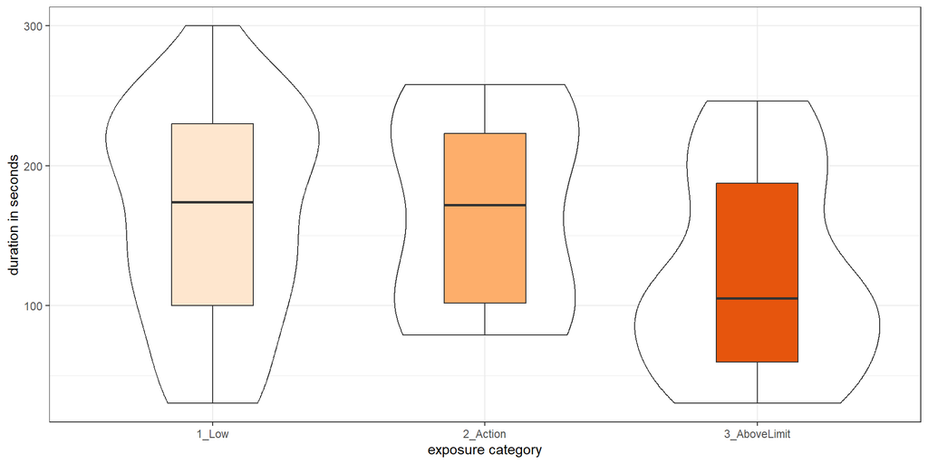

# Fitting `polr` models with the `MASS::polr` function

## Proportional-Odds Cumulative Logit

We’ll use the `polr` function in the **MASS** package.

- Clearly, exposure group (3) Above legal limit, is worst, followed by group (2) Action level, and then group (1) Low exposure.
- We’ll have two binary (1/0) predictors (one for task and one for ventilation) and one quantitative predictor (for duration).

## Equations to be Fit

- The model will have two logit equations: one comparing group (1) to group (2) and one comparing group (2) to group (3), and three slopes, for a total of five free parameters.

$$log(\frac{Pr(exposure \leq 1)}{Pr(exposure > 1)}) = \beta_{0[1]} + \beta_1 task + \beta_2 vent. + \beta_3 duration$$

and

$$log(\frac{Pr(exposure \leq 2)}{Pr(exposure > 2)}) = \beta_{0[2]} + \beta_1 task + \beta_2 vent. + \beta_3 duration$$

## Centering `Duration`

In order to make our result more interpretable, I suggest we center each of our quantitative predictors (in this case, that’s just centering duration.) Recall that `mean(duration)` = 147.1 minutes in these data.

```r
asbestos <- asbestos |>
  mutate(dur_c = duration - mean(duration))
```

A value of `dur_c` = 0 thus means that we have the mean level of `duration`.

## Model Equations

Note that the intercept term is the only piece that varies across the two equations shown in the previous slide.

- A positive coefficient $\beta$ means that increasing the value of that predictor tends to *raise* the exposure category, and thus *increase* the asbestos exposure.

### Fitting the Model

```r
modelA <- polr(exposure ~ task + ventilation + dur_c,
                data=asbestos, Hess = TRUE)
```

## Model Summary

```r
summary(modelA)
```

```
Call:
polr(formula = exposure ~ task + ventilation + dur_c, data = asbestos,
    Hess = TRUE)

Coefficients:
                       Value Std. Error t value
taskInsulation      2.251344   0.644593  3.4927
ventilationGeneral  2.156963   0.567535  3.8006
dur_c              -0.000708   0.003797 -0.1865

Intercepts:
                      Value   Std. Error t value
1_Low|2_Action         2.4550  0.5714     4.2963
2_Action|3_AboveLimit  3.0013  0.6094     4.9248

Residual Deviance: 99.87952
AIC: 109.8795
```

## Direction of Model Effects

Here are coefficient estimates for the three predictors.

```r
tidy(modelA) |> filter(coef.type == "coefficient") |>
  gt() |> fmt_number(decimals = 3) |>
  tab_options(table.font.size = 20)
```

| term | estimate | std.error | statistic | coef.type |
| --- | --- | --- | --- | --- |
| taskInsulation | 2.251 | 0.645 | 3.493 | coefficient |
| ventilationGeneral | 2.157 | 0.568 | 3.801 | coefficient |
| dur_c | −0.001 | 0.004 | −0.186 | coefficient |

- The estimated slope for task = Insulation is 2.25.
  - Since the slope is positive, `task` = Insulation produces an *increased* `exposure` level compared to `task` = Tile when `ventilation` and `duration` are held constant.

## Effect of Task via Odds Ratio + CI

```r
tidy(modelA, exponentiate = TRUE, conf.int = TRUE) |>
  filter(coef.type == "coefficient") |>
  gt() |> fmt_number(decimals = 3) |> tab_options(table.font.size = 20)
```

| term | estimate | std.error | statistic | conf.low | conf.high | coef.type |
| --- | --- | --- | --- | --- | --- | --- |
| taskInsulation | 9.500 | 0.645 | 3.493 | 2.826 | 36.787 | coefficient |
| ventilationGeneral | 8.645 | 0.568 | 3.801 | 2.917 | 27.465 | coefficient |
| dur_c | 0.999 | 0.004 | −0.186 | 0.992 | 1.007 | coefficient |

- Assuming `ventilation` and `duration` remain constant, suppose Al has `task` = Insulation and Bob has `task` = Tile.
- `modelA`: Odds of higher asbestos `exposure` are 9.5 (95% CI 2.8 to 36.8) times as large for Al as they are for Bob.

## Ventilation Effect

```r
tidy(modelA, exponentiate = TRUE, conf.int = TRUE) |>
  filter(coef.type == "coefficient") |>
  gt() |> fmt_number(decimals = 3) |> tab_options(table.font.size = 20)
```

| term | estimate | std.error | statistic | conf.low | conf.high | coef.type |
| --- | --- | --- | --- | --- | --- | --- |
| taskInsulation | 9.500 | 0.645 | 3.493 | 2.826 | 36.787 | coefficient |
| ventilationGeneral | 8.645 | 0.568 | 3.801 | 2.917 | 27.465 | coefficient |
| dur_c | 0.999 | 0.004 | −0.186 | 0.992 | 1.007 | coefficient |

- Assuming `task` and `duration` remain constant, `modelA` suggests the odds of higher `exposure` are 8.65 (95% CI 2.9, 27.5) times as large when using General ventilation.
- Impact of `duration` appears quite small: odds ratio is essentially 1, with 95% CI (0.99, 1.01).

## `modelA`: Equation 1

```r
tidy(modelA) |>
  gt() |> fmt_number(decimals = 3) |> tab_options(table.font.size = 20)
```

| term | estimate | std.error | statistic | coef.type |
| --- | --- | --- | --- | --- |
| taskInsulation | 2.251 | 0.645 | 3.493 | coefficient |
| ventilationGeneral | 2.157 | 0.568 | 3.801 | coefficient |
| dur_c | −0.001 | 0.004 | −0.186 | coefficient |
| 1_Low\|2_Action | 2.455 | 0.571 | 4.296 | scale |
| 2_Action\|3_AboveLimit | 3.001 | 0.609 | 4.925 | scale |

- 2.455 is the estimated log odds of falling into category (1) low exposure versus all other categories, when all other predictors (task, ventilation and centered duration) are zero.

## `modelA`: Equation 2

```r
tidy(modelA) |>
  gt() |> fmt_number(decimals = 3) |> tab_options(table.font.size = 20)
```

| term | estimate | std.error | statistic | coef.type |
| --- | --- | --- | --- | --- |
| taskInsulation | 2.251 | 0.645 | 3.493 | coefficient |
| ventilationGeneral | 2.157 | 0.568 | 3.801 | coefficient |
| dur_c | −0.001 | 0.004 | −0.186 | coefficient |
| 1_Low\|2_Action | 2.455 | 0.571 | 4.296 | scale |
| 2_Action\|3_AboveLimit | 3.001 | 0.609 | 4.925 | scale |

- 3.001 is the estimated log odds of falling into category (1) or (2) versus category (3), when all other predictors (task, ventilation and centered duration) are zero.

## `modelA` First Equation

```r
tidy(modelA) |>
  gt() |> fmt_number(decimals = 3) |> tab_options(table.font.size = 20)
```

| term | estimate | std.error | statistic | coef.type |
| --- | --- | --- | --- | --- |
| taskInsulation | 2.251 | 0.645 | 3.493 | coefficient |
| ventilationGeneral | 2.157 | 0.568 | 3.801 | coefficient |
| dur_c | −0.001 | 0.004 | −0.186 | coefficient |
| 1_Low\|2_Action | 2.455 | 0.571 | 4.296 | scale |
| 2_Action\|3_AboveLimit | 3.001 | 0.609 | 4.925 | scale |

$$log(\frac{Pr(exposure \leq 1)}{Pr(exposure > 1)}) =$$

$$2.46 + 2.25 [task=Ins.] + 2.16 [vent=General] - 0.001 dur_c$$

## `modelA` Second Equation

```r
tidy(modelA) |>
  gt() |> fmt_number(decimals = 3) |> tab_options(table.font.size = 20)
```

| term | estimate | std.error | statistic | coef.type |
| --- | --- | --- | --- | --- |
| taskInsulation | 2.251 | 0.645 | 3.493 | coefficient |
| ventilationGeneral | 2.157 | 0.568 | 3.801 | coefficient |
| dur_c | −0.001 | 0.004 | −0.186 | coefficient |
| 1_Low\|2_Action | 2.455 | 0.571 | 4.296 | scale |
| 2_Action\|3_AboveLimit | 3.001 | 0.609 | 4.925 | scale |

$$log(\frac{Pr(exposure \leq 2)}{Pr(exposure > 2)}) =$$

$$3.00 + 2.25 [task=Ins.] + 2.16 [vent=General] - 0.001 dur_c$$

# Comparing `polr` models

## `modelA` vs. “Intercept only” model

```r
model.1 <- polr(exposure ~ 1, data=asbestos)
anova(model.1, modelA) |>
  gt() |> tab_options(table.font.size = 20)
```

| Model | Resid. df | Resid. Dev | Test | Df | LR stat. | Pr(Chi) |
| --- | --- | --- | --- | --- | --- | --- |
| 1 | 81 | 147.61971 |  | NA | NA | NA |
| task + ventilation + dur_c | 78 | 99.87952 | 1 vs 2 | 3 | 47.74019 | 2.41857e-10 |

### Can we compare AIC and BIC?

```r
AIC(model.1, modelA)
```

```
        df      AIC
model.1  2 151.6197
modelA   5 109.8795
```

```r
BIC(model.1, modelA)
```

```
        df      BIC
model.1  2 156.4574
modelA   5 121.9737
```

## `modelA` vs. “No duration” Model

Compare to a model with just Task and Ventilation

```r
modelTV <- polr(exposure ~ task + ventilation, data=asbestos)
anova(modelA, modelTV) |>
  gt() |> tab_options(table.font.size = 20)
```

| Model | Resid. df | Resid. Dev | Test | Df | LR stat. | Pr(Chi) |
| --- | --- | --- | --- | --- | --- | --- |
| task + ventilation | 79 | 99.91421 |  | NA | NA | NA |
| task + ventilation + dur_c | 78 | 99.87952 | 1 vs 2 | 1 | 0.03469476 | 0.8522367 |

```r
AIC(modelA, modelTV)
```

```
        df      AIC
modelA   5 109.8795
modelTV  4 107.9142
```

```r
BIC(modelA, modelTV)
```

```
        df      BIC
modelA   5 121.9737
modelTV  4 117.5896
```

## task*ventilation interaction?

```r
model.TxV <- polr(exposure ~ task * ventilation, data=asbestos)
anova(modelTV, model.TxV) |>
  gt() |> tab_options(table.font.size = 20)
```

| Model | Resid. df | Resid. Dev | Test | Df | LR stat. | Pr(Chi) |
| --- | --- | --- | --- | --- | --- | --- |
| task + ventilation | 79 | 99.91421 |  | NA | NA | NA |
| task * ventilation | 78 | 99.64326 | 1 vs 2 | 1 | 0.2709469 | 0.6026973 |

```r
AIC(modelTV, model.TxV)
```

```
          df      AIC
modelTV    4 107.9142
model.TxV  5 109.6433
```

```r
BIC(modelTV, model.TxV)
```

```
          df      BIC
modelTV    4 117.5896
model.TxV  5 121.7375
```

## Fitting all of the models?

Well, not all of the models, but the interesting ones?

```r
m1 <- polr(exposure ~ 1, data = asbestos)
m2 <- polr(exposure ~ dur_c, data = asbestos)
m3 <- polr(exposure ~ task, data = asbestos)
m4 <- polr(exposure ~ ventilation, data = asbestos)
m5 <- polr(exposure ~ task + ventilation, data = asbestos)
m6 <- polr(exposure ~ task * ventilation, data = asbestos)
m7 <- polr(exposure ~ task + ventilation + dur_c, data = asbestos)

anova(m2, m1)
```

```
Likelihood ratio tests of ordinal regression models

Response: exposure
  Model Resid. df Resid. Dev   Test    Df LR stat.    Pr(Chi)
1     1        81   147.6197
2 dur_c        80   142.2944 1 vs 2     1 5.325273 0.02101831
```

## `asbestos` Likelihood Ratio Tests

| Model | Elements | DF | Deviance | Test | *p* |
| --- | --- | --- | --- | --- | --- |
| 1 | Intercept | 81 | 147.62 | – | – |
| 2 | Duration | 80 | 142.29 | vs 1 | 0.021 |
| 3 | Task | 80 | 115.36 | vs 1 | < 0.0001 |
| 4 | Ventilation | 80 | 115.45 | vs 1 | < 0.0001 |
| 5 | T+V | 79 | 99.91 | vs 3 | < 0.0001 |
| 6 | T*V | 78 | 99.64 | vs 5 | 0.603 |
| 7 | T+V+D | 78 | 99.88 | vs 5 | 0.852 |

## Predictions with our `T+V` model

```r
modelTV <- polr(exposure ~ task + ventilation, data=asbestos)
asbestos <- asbestos |> mutate(TV_preds = predict(modelTV))
asbestos |> tabyl(TV_preds, exposure) |> adorn_title()
```

```
              exposure
     TV_preds    1_Low 2_Action 3_AboveLimit
        1_Low       42        3           10
     2_Action        0        0            0
 3_AboveLimit        3        3           22
```

- Predicting Low exposure led to 42 right and 13 wrong.
- We never predicted Action Level
- Predicting Above Legal Limit led to 22 right and 6 wrong.

Total: 64 right, 19 wrong. Accuracy = 64/83 = 77.1%

## Proportional odds assumption reasonable?

Alternative: fit a multinomial model?

```r
mult_TV <- multinom(exposure ~ task + ventilation,
                       data = asbestos, trace = FALSE)
mult_TV
```

```
Call:
multinom(formula = exposure ~ task + ventilation, data = asbestos,
    trace = FALSE)

Coefficients:
             (Intercept) taskInsulation ventilationGeneral
2_Action       -3.423661       1.159959           2.316383
3_AboveLimit   -3.117443       2.699791           2.495969

Residual Deviance: 98.08263
AIC: 110.0826
```

## Multinomial `T+V` model predicts…

```r
asbestos <- asbestos |>
  mutate(TVmult_preds = predict(mult_TV))
asbestos |> tabyl(TVmult_preds, exposure) |> adorn_title()
```

```
              exposure
 TVmult_preds    1_Low 2_Action 3_AboveLimit
        1_Low       42        3           10
     2_Action        0        0            0
 3_AboveLimit        3        3           22
```

- Exactly the same predictions as our `polr` model.

```r
asbestos |> count(TVmult_preds, TV_preds)
```

```
# A tibble: 2 × 3
  TVmult_preds TV_preds         n
  <fct>        <fct>        <int>
1 1_Low        1_Low           55
2 3_AboveLimit 3_AboveLimit    28
```

## Compare Models with Likelihood Ratio Test?

```r
(LL_multTV <- logLik(mult_TV)) # multinomial model: 6 df
```

```
'log Lik.' -49.04131 (df=6)
```

```r
(LL_polrTV <- logLik(modelTV)) # polr model: 4 df
```

```
'log Lik.' -49.9571 (df=4)
```

```r
(G = -2 * (LL_polrTV[1] - LL_multTV[1]))
```

```
[1] 1.831584
```

```r
pchisq(G, 2, lower.tail = FALSE)
```

```
[1] 0.4001995
```

*p* = 0.4 testing the difference in goodness of fit between the proportional odds model and the more complex multinomial logistic regression model.

## AIC and BIC for multinomial vs. polr models

```r
AIC(mult_TV, modelTV)
```

```
        df      AIC
mult_TV  6 110.0826
modelTV  4 107.9142
```

```r
BIC(mult_TV, modelTV)
```

```
        df      BIC
mult_TV  6 124.5957
modelTV  4 117.5896
```

- `mult_TV` is the multinomial model
- `modelTV` is the polr model

# Using `rms` to fit the POLR model via `lrm()`

## Proportional Odds Ordinal Logistic Regression with `lrm()`

```r
d <- datadist(asbestos)
options(datadist = "d")

# note that exposure must be an ordered factor

model_TV_LRM <- lrm(exposure ~ task + ventilation,
                 data = asbestos, x = TRUE, y = TRUE)
```

## The `lrm()` fit

```r
model_TV_LRM
```

```
Logistic Regression Model

lrm(formula = exposure ~ task + ventilation, data = asbestos,
    x = TRUE, y = TRUE)

                       Model Likelihood    Discrimination    Rank Discrim.
                             Ratio Test           Indexes          Indexes
Obs            83    LR chi2      47.71    R2       0.526    C       0.854
 1_Low         45    d.f.             2    R2(2,83) 0.423    Dxy     0.708
 2_Action       6    Pr(> chi2) <0.0001    R2(2,65) 0.505    gamma   0.839
 3_AboveLimit  32                          Brier    0.127    tau-a   0.396
max |deriv| 3e-10

                    Coef    S.E.   Wald Z Pr(>|Z|)
y>=2_Action         -2.4751 0.5613 -4.41  <0.0001
y>=3_AboveLimit     -3.0208 0.6005 -5.03  <0.0001
task=Insulation      2.2868 0.6173  3.70  0.0002
ventilation=General  2.1596 0.5675  3.81  0.0001
```

## Effects Plot after `lrm()`

```r
plot(summary(model_TV_LRM))
```

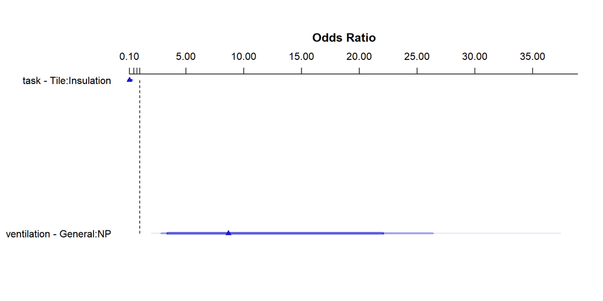

## `lrm()` fit, plotted on log odds scale

```r
ggplot(Predict(model_TV_LRM), layout = c(1,2))
```

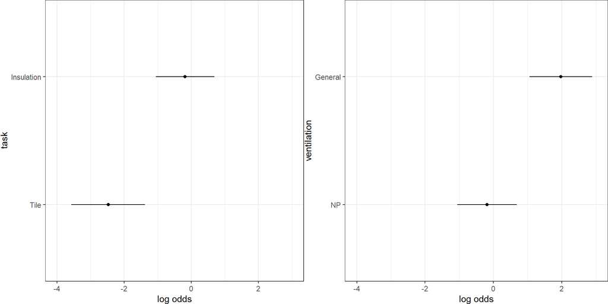

## `lrm()` fit, on probability scale

```r
ggplot(Predict(model_TV_LRM, fun = plogis), layout = c(1,2))
```

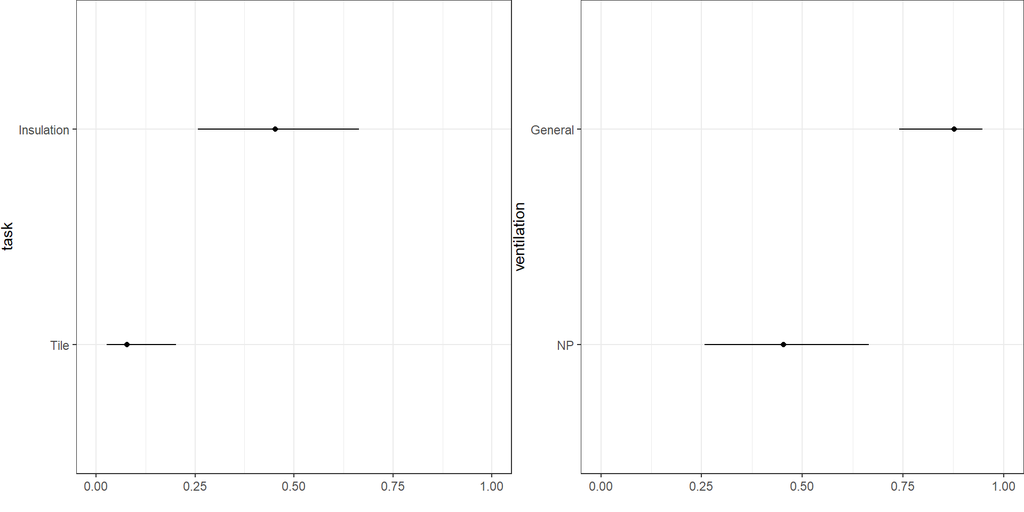

## `rms::validate` results from `lrm()`

```r
set.seed(432001)
validate(model_TV_LRM)
```

```
          index.orig training    test optimism index.corrected  n
Dxy           0.7077   0.7194  0.7081   0.0112          0.6964 40
R2            0.5260   0.5449  0.5210   0.0239          0.5021 40
Intercept     0.0000   0.0000  0.0093  -0.0093          0.0093 40
Slope         1.0000   1.0000  0.9414   0.0586          0.9414 40
Emax          0.0000   0.0000  0.0149   0.0149          0.0149 40
D             0.5627   0.5946  0.5554   0.0392          0.5235 40
U            -0.0241  -0.0241 -0.3980   0.3739         -0.3980 40
Q             0.5868   0.6187  0.9534  -0.3347          0.9216 40
B             0.1270   0.1205  0.1315  -0.0109          0.1379 40
g             2.0639   2.1935  2.0426   0.1508          1.9131 40
gp            0.3709   0.3755  0.3708   0.0047          0.3662 40
```

Validated $C$ = 0.5 + (0.6964/2) = 0.8482

## All possible combinations of T and V

```r
newdat <- data.frame(
  worker = c("New1", "New2", "New3", "New4"),
  task = c("Tile", "Tile", "Insulation", "Insulation"),
  ventilation = c("NP", "General", "NP", "General")
) |>
  mutate(task = factor(task),
         ventilation = factor(ventilation))

newdat ## note this is NOT a tibble
```

```
  worker       task ventilation
1   New1       Tile          NP
2   New2       Tile     General
3   New3 Insulation          NP
4   New4 Insulation     General
```

## Add individual predictions

We use `predict()` with `type = "fitted.ind"` here.

```r
newdat_aug <- cbind(newdat,
      predict(model_TV_LRM, newdata = newdat, type = "fitted.ind"))

newdat_aug |> gt() |> fmt_number(decimals = 3) |>
  tab_options(table.font.size = 20)
```

| worker | task | ventilation | exposure=1_Low | exposure=2_Action | exposure=3_AboveLimit |
| --- | --- | --- | --- | --- | --- |
| New1 | Tile | NP | 0.922 | 0.031 | 0.046 |
| New2 | Tile | General | 0.578 | 0.125 | 0.297 |
| New3 | Insulation | NP | 0.547 | 0.129 | 0.324 |
| New4 | Insulation | General | 0.122 | 0.072 | 0.806 |

## Instead add fitted predictions?

Using `type = "fitted"` produces greater than or equal to predictions instead.

```r
newdat_aug2 <- cbind(newdat,
      predict(model_TV_LRM, newdata = newdat, type = "fitted"))

newdat_aug2 |> gt() |> fmt_number(decimals = 3) |>
  tab_options(table.font.size = 20)
```

| worker | task | ventilation | y>=2_Action | y>=3_AboveLimit |
| --- | --- | --- | --- | --- |
| New1 | Tile | NP | 0.078 | 0.046 |
| New2 | Tile | General | 0.422 | 0.297 |
| New3 | Insulation | NP | 0.453 | 0.324 |
| New4 | Insulation | General | 0.878 | 0.806 |

# Ordinal Logistic Regression with `orm()` from rms

## `orm()` vs. `lrm()` differences?

- In fitting an `orm()` vs. `lrm()`, just using the letter “o” instead of “l”.
- The `orm()` model: appropriate when we are interested in studying the rank correlation between the predictions and the outcomes - in essence, we are interested in “penalizing” more for being two categories away from correct than being one category away from correct.
- The `lrm()` or `polr()` model: appropriate when we are interested in “penalizing” all incorrect predictions the same way.

## Ordinal Logistic Regression for `T+V` with `orm`

```r
d <- datadist(asbestos)
options(datadist = "d")

model_TV_ORM <- orm(exposure ~ task + ventilation,
                 data = asbestos, x = TRUE, y = TRUE)

# note that exposure must be an ordered factor
```

## `model_TV_ORM` fit with `orm`

```r
model_TV_ORM
```

```
Logistic (Proportional Odds) Ordinal Regression Model

orm(formula = exposure ~ task + ventilation, data = asbestos,
    x = TRUE, y = TRUE)

                       Model Likelihood               Discrimination    Rank Discrim.
                             Ratio Test                      Indexes          Indexes
Obs            83    LR chi2      47.71    R2                  0.526    rho     0.697
 1_Low         45    d.f.             2    R2(2,83)            0.423
 2_Action       6    Pr(> chi2) <0.0001    R2(2,65)            0.505
 3_AboveLimit  32    Score chi2   42.42    |Pr(Y>=median)-0.5| 0.301
Distinct Y      3    Pr(> chi2) <0.0001
Median Y        1
max |deriv| 6e-05

                    Coef    S.E.   Wald Z Pr(>|Z|)
y>=2_Action         -2.4751 0.5613 -4.41  <0.0001
y>=3_AboveLimit     -3.0208 0.6005 -5.03  <0.0001
task=Insulation      2.2868 0.6173  3.70  0.0002
ventilation=General  2.1596 0.5675  3.81  0.0001
```

## Effects Plot from `orm`

```r
plot(summary(model_TV_ORM))
```

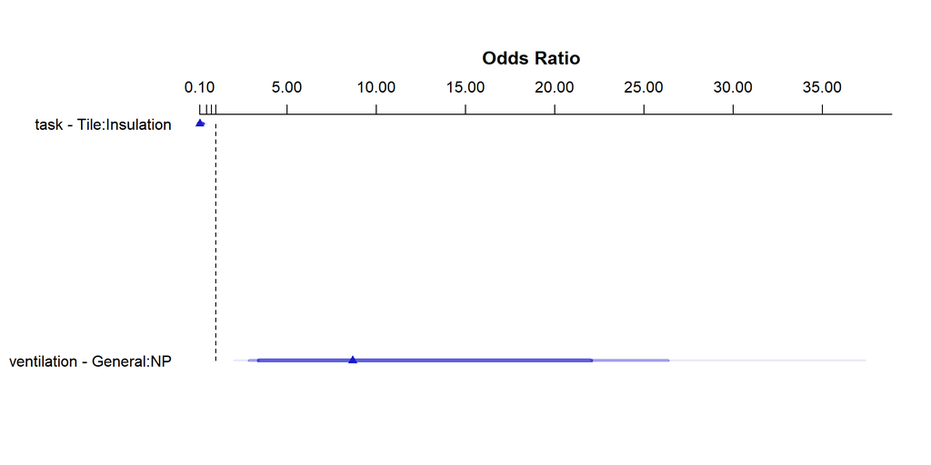

## POLR model fit with `orm`, plotted

```r
ggplot(Predict(model_TV_ORM, fun = plogis), layout = c(1,2))
```

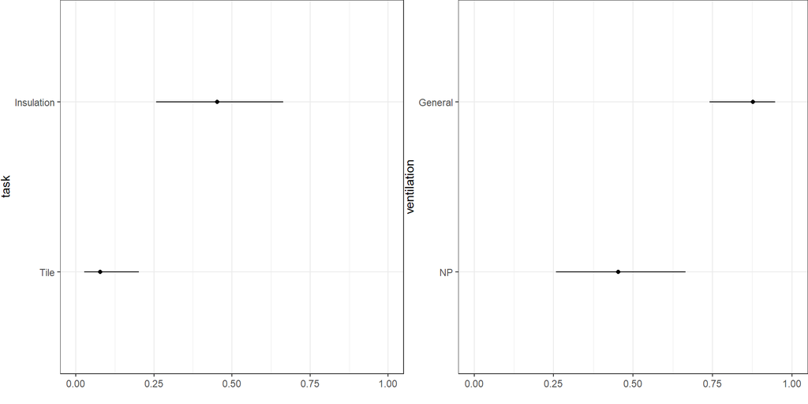

## `rms::validate` results from `orm`

```r
set.seed(432002)
validate(model_TV_ORM)
```

```
      index.orig training   test optimism index.corrected  n
rho       0.6970   0.6916 0.6976  -0.0060          0.7031 40
R2        0.5260   0.5288 0.5156   0.0132          0.5128 40
Slope     1.0000   1.0000 0.9612   0.0388          0.9612 40
g         2.0639   2.2268 2.0136   0.2132          1.8508 40
pdm       0.3010   0.3109 0.3051   0.0058          0.2952 40
```

- `rho` = Spearman’s rank correlation between linear predictor and outcome
- `R2` = Nagelkerke R-square

## Predicting with `orm()`

We can from the information below, estimate the model probability of obtaining each of the three possible results.

```r
newdat_aug3 <- cbind(newdat,
      predict(model_TV_ORM, newdata = newdat, type = "fitted"))

newdat_aug2 |> gt() |> fmt_number(decimals = 3) |>
  tab_options(table.font.size = 20)
```

| worker | task | ventilation | y>=2_Action | y>=3_AboveLimit |
| --- | --- | --- | --- | --- |
| New1 | Tile | NP | 0.078 | 0.046 |
| New2 | Tile | General | 0.422 | 0.297 |
| New3 | Insulation | NP | 0.453 | 0.324 |
| New4 | Insulation | General | 0.878 | 0.806 |

## Conclusions?

We can fit both POLR models and ordinal regression models with `rms` approaches, and we can also fit POLR with `MASS::polr()`.

- All are designed for *ordinal* multi-categorical outcomes.
- Can compare results to what we would get with multinomial models, designed for *nominal* multi-categorical outcomes.

We’ll focus on regression for *nominal* multi-categorical outcomes next time.

432 Class 18 | 2024-03-21 | https://thomaselove.github.io/432-2024/